In what follows, please find the results of additional analyses: variance inflation factors, the originally preregistered model, results without covariates, results with all participants (hence, including those removed due to speeding or response patterns), and frequentist robustness and moderation analyses. For the main analyses, see Analyses.

All analyses on this page focus on communication (the number of words), the main outcome of the study. Self-disclosure is only analyzed in the main analyses, because it is addressed in one additional research question (RQ2).

# Setup

Load packages.

```r
# define packages
packages <-
  c(
    "cowplot"
    , "devtools"
    , "faoutlier"
    , "GGally"
    , "kableExtra"
    , "knitr"
    , "lavaan"
    , "magrittr"
    , "MVN"
    , "psych"
    , "pwr"
    , "quanteda"
    , "semTools"
    , "td"
    , "tidyverse"
    )

# load packages
lapply(
  packages
  , library
  , character.only = TRUE
  , quietly = TRUE
  )
```

Load data.

```r
# load workspace (created in the main analyses)
load("data/workspace.RData")

# originally preregistered outcome: words + reactions (likes/dislikes count twice), log-transformed
d$words_react_log <- log1p(d$words + 2 * d$reactions)
```

# Variance Inflation Factors

In what follows, you can find estimations of variance inflation factors, which help gauge multicollinearity. Generally, values above 5 or even 10 are considered problematic. However, these are only rules of thumb, and multicollinearity can occur with lower values. Indeed, although the values reported below are not above 5, they are increased, suggesting that multicollinearity might be at play here, which the preregistered analyses also confirm.

Each variable is regressed on all other privacy calculus variables (controlling for gender, age, and education). The VIF is then computed from the explained variance: VIF = 1 / (1 − R²). As in the preregistered analyses, trust is measured as specific trust here.

*Self-efficacy* regressed on the other variables:

```r
model <- "
pri_con =~ PC01_01 + PC01_02 + PC01_04 + PC01_05 + PC01_06 + PC01_07
grats_gen =~ GR02_01 + GR02_02 + GR02_03 + GR02_04 + GR02_05
pri_delib =~ PD01_01 + PD01_02 + PD01_03 + PD01_04 + PD01_05
self_eff =~ SE01_01 + SE01_02 + SE01_03 + SE01_04
SE01_01 ~~ a*SE01_02
SE01_03 ~~ a*SE01_04
trust_community =~ TR01_01 + TR01_02 + TR01_03
trust_provider =~ TR01_04 + TR01_05 + TR01_06 + TR01_07 + TR01_08 + TR01_09
trust_spec =~ trust_community + trust_provider

self_eff ~ pri_con + grats_gen + pri_delib + trust_spec

# Covariates
GR02_01 + GR02_02 + GR02_03 + GR02_04 + GR02_05 + PC01_01 + PC01_02 + PC01_04 + PC01_05 + PC01_06 + PC01_07 + TR01_01 + TR01_02 + TR01_03 + TR01_04 + TR01_05 + TR01_06 + TR01_07 + TR01_08 + TR01_09 + PD01_01 + PD01_02 + PD01_03 + PD01_04 + PD01_05 + SE01_01 + SE01_02 + SE01_03 + SE01_04 ~ male + age + edu
"
fit <- sem(model, data = d, estimator = "MLR", missing = "ML")
r_self_eff <- inspect(fit, what = "rsquare")["self_eff"] # extract rsquare
vif_self_eff <- 1 / (1 - r_self_eff) # compute vif
```

*Privacy deliberation* regressed on the other variables:

```r
model <- "
pri_con =~ PC01_01 + PC01_02 + PC01_04 + PC01_05 + PC01_06 + PC01_07
grats_gen =~ GR02_01 + GR02_02 + GR02_03 + GR02_04 + GR02_05
pri_delib =~ PD01_01 + PD01_02 + PD01_03 + PD01_04 + PD01_05
self_eff =~ SE01_01 + SE01_02 + SE01_03 + SE01_04
SE01_01 ~~ a*SE01_02
SE01_03 ~~ a*SE01_04
trust_community =~ TR01_01 + TR01_02 + TR01_03
trust_provider =~ TR01_04 + TR01_05 + TR01_06 + TR01_07 + TR01_08 + TR01_09
trust_spec =~ trust_community + trust_provider
pri_delib ~ self_eff + pri_con + grats_gen + trust_spec

# Covariates
GR02_01 + GR02_02 + GR02_03 + GR02_04 + GR02_05 + PC01_01 + PC01_02 + PC01_04 + PC01_05 + PC01_06 + PC01_07 + TR01_01 + TR01_02 + TR01_03 + TR01_04 + TR01_05 + TR01_06 + TR01_07 + TR01_08 + TR01_09 + PD01_01 + PD01_02 + PD01_03 + PD01_04 + PD01_05 + SE01_01 + SE01_02 + SE01_03 + SE01_04 ~ male + age + edu
"
fit <- sem(model, data = d, estimator = "MLR", missing = "ML")
r_pri_delib <- inspect(fit, what = "rsquare")["pri_delib"]
vif_pri_delib <- 1 / (1 - r_pri_delib)
```

*Privacy concerns* regressed on the other variables:

```r
model <- "
pri_con =~ PC01_01 + PC01_02 + PC01_04 + PC01_05 + PC01_06 + PC01_07
grats_gen =~ GR02_01 + GR02_02 + GR02_03 + GR02_04 + GR02_05
pri_delib =~ PD01_01 + PD01_02 + PD01_03 + PD01_04 + PD01_05
self_eff =~ SE01_01 + SE01_02 + SE01_03 + SE01_04
SE01_01 ~~ a*SE01_02
SE01_03 ~~ a*SE01_04
trust_community =~ TR01_01 + TR01_02 + TR01_03
trust_provider =~ TR01_04 + TR01_05 + TR01_06 + TR01_07 + TR01_08 + TR01_09
trust_spec =~ trust_community + trust_provider

pri_con ~ self_eff + pri_delib + grats_gen + trust_spec

# Covariates
GR02_01 + GR02_02 + GR02_03 + GR02_04 + GR02_05 + PC01_01 + PC01_02 + PC01_04 + PC01_05 + PC01_06 + PC01_07 + TR01_01 + TR01_02 + TR01_03 + TR01_04 + TR01_05 + TR01_06 + TR01_07 + TR01_08 + TR01_09 + PD01_01 + PD01_02 + PD01_03 + PD01_04 + PD01_05 + SE01_01 + SE01_02 + SE01_03 + SE01_04 ~ male + age + edu
"
fit <- sem(model, data = d, estimator = "MLR", missing = "ML")
r_pri_con <- inspect(fit, what = "rsquare")["pri_con"]
vif_pri_con <- 1 / (1 - r_pri_con)
```

*Gratifications* regressed on the other variables:

```r
model <- "
pri_con =~ PC01_01 + PC01_02 + PC01_04 + PC01_05 + PC01_06 + PC01_07
grats_gen =~ GR02_01 + GR02_02 + GR02_03 + GR02_04 + GR02_05
pri_delib =~ PD01_01 + PD01_02 + PD01_03 + PD01_04 + PD01_05
self_eff =~ SE01_01 + SE01_02 + SE01_03 + SE01_04
SE01_01 ~~ a*SE01_02
SE01_03 ~~ a*SE01_04
trust_community =~ TR01_01 + TR01_02 + TR01_03
trust_provider =~ TR01_04 + TR01_05 + TR01_06 + TR01_07 + TR01_08 + TR01_09
trust_spec =~ trust_community + trust_provider
grats_gen ~ self_eff + pri_con + pri_delib + trust_spec

# Covariates
GR02_01 + GR02_02 + GR02_03 + GR02_04 + GR02_05 + PC01_01 + PC01_02 + PC01_04 + PC01_05 + PC01_06 + PC01_07 + TR01_01 + TR01_02 + TR01_03 + TR01_04 + TR01_05 + TR01_06 + TR01_07 + TR01_08 + TR01_09 + PD01_01 + PD01_02 + PD01_03 + PD01_04 + PD01_05 + SE01_01 + SE01_02 + SE01_03 + SE01_04 ~ male + age + edu
"
fit <- sem(model, data = d, estimator = "MLR", missing = "ML")
r_grats_gen <- inspect(fit, what = "rsquare")["grats_gen"]
vif_grats_gen <- 1 / (1 - r_grats_gen)
```

*Trust* regressed on the other variables:

```r
model <- "
pri_con =~ PC01_01 + PC01_02 + PC01_04 + PC01_05 + PC01_06 + PC01_07
grats_gen =~ GR02_01 + GR02_02 + GR02_03 + GR02_04 + GR02_05
pri_delib =~ PD01_01 + PD01_02 + PD01_03 + PD01_04 + PD01_05
self_eff =~ SE01_01 + SE01_02 + SE01_03 + SE01_04
SE01_01 ~~ a*SE01_02
SE01_03 ~~ a*SE01_04
trust_community =~ TR01_01 + TR01_02 + TR01_03
trust_provider =~ TR01_04 + TR01_05 + TR01_06
trust_system =~ TR01_07 + TR01_08 + TR01_09
trust_spec =~ trust_community + trust_provider + trust_system

trust_spec ~ self_eff + pri_con + grats_gen + pri_delib

# Covariates
GR02_01 + GR02_02 + GR02_03 + GR02_04 + GR02_05 + PC01_01 + PC01_02 + PC01_04 + PC01_05 + PC01_06 + PC01_07 + TR01_01 + TR01_02 + TR01_03 + TR01_04 + TR01_05 + TR01_06 + TR01_07 + TR01_08 + TR01_09 + PD01_01 + PD01_02 + PD01_03 + PD01_04 + PD01_05 + SE01_01 + SE01_02 + SE01_03 + SE01_04 ~ male + age + edu
"
fit <- sem(model, data = d, estimator = "MLR", missing = "ML")
r_trust_spec <- inspect(fit, what = "rsquare")["trust_spec"]
vif_trust_spec <- 1 / (1 - r_trust_spec)
```

The table summarizes the VIFs of all five variables.

```r
# Table
tibble("Gratifications" = vif_grats_gen, "Trust Specific" = vif_trust_spec, "Privacy Concerns" = vif_pri_con, "Privacy Deliberation" = vif_pri_delib, "Self-Efficacy" = vif_self_eff) %>%
  kable() %>%
  kable_styling("striped")
```

| Gratifications | Trust Specific | Privacy Concerns | Privacy Deliberation | Self-Efficacy |
| --- | --- | --- | --- | --- |
| 2.73 | 3.14 | 1.61 | 1.51 | 1.51 |

# Originally Preregistered Model

We first analyze the model as it was initially preregistered. In the original preregistration, the outcome was communication including reactions: the number of words plus twice the number of likes and dislikes given, log-transformed (see Open Science and Preregistration). Trust was modeled as one factor combining general and specific trust.

```r
model <- "
pri_con =~ PC01_01 + PC01_02 + PC01_04 + PC01_05 + PC01_06 + PC01_07
grats_gen =~ GR02_01 + GR02_02 + GR02_03 + GR02_04 + GR02_05
pri_delib =~ PD01_01 + PD01_02 + PD01_03 + PD01_04 + PD01_05
self_eff =~ SE01_01 + SE01_02 + SE01_03 + SE01_04
  SE01_01 ~~ x*SE01_02
  SE01_03 ~~ x*SE01_04
trust_community =~ TR02_01 + TR01_01 + TR01_02 + TR01_03
trust_provider =~ TR02_02 + TR01_04 + TR01_05 + TR01_06
trust_system =~ TR02_03 + TR01_07 + TR01_08 + TR01_09
trust =~ trust_community + trust_provider + trust_system

words_react_log ~ a1*pri_con + b1*grats_gen + c1*pri_delib + d1*self_eff + e1*trust

# Covariates
words_react_log + GR02_01 + GR02_02 + GR02_03 + GR02_04 + GR02_05 + PC01_01 + PC01_02 + PC01_04 + PC01_05 + PC01_06 + PC01_07 + TR02_01 + TR02_02 + TR02_03 + TR01_01 + TR01_02 + TR01_03 + TR01_04 + TR01_05 + TR01_06 + TR01_07 + TR01_08 + TR01_09 + PD01_01 + PD01_02 + PD01_03 + PD01_04 + PD01_05 + SE01_01 + SE01_02 + SE01_03 + SE01_04 ~ male + age + edu
"
fit_prereg <- sem(model, data = d, estimator = "MLR", missing = "ML")
summary(fit_prereg, fit = TRUE, std = TRUE)
```

```
lavaan 0.6-20 ended normally after 371 iterations

  Estimator                                         ML
  Optimization method                           NLMINB
  Number of model parameters                       217
  Number of equality constraints                     1

                                                  Used       Total
  Number of observations                           558         559
  Number of missing patterns                         3

Model Test User Model:
                                              Standard      Scaled
  Test Statistic                              1586.064    1215.351
  Degrees of freedom                               477         477
  P-value (Chi-square)                           0.000       0.000
  Scaling correction factor                                  1.305
    Yuan-Bentler correction (Mplus variant)

Model Test Baseline Model:

  Test statistic                             15518.638   11639.461
  Degrees of freedom                               627         627
  P-value                                        0.000       0.000
  Scaling correction factor                                  1.333

User Model versus Baseline Model:

  Comparative Fit Index (CFI)                    0.926       0.933
  Tucker-Lewis Index (TLI)                       0.902       0.912

  Robust Comparative Fit Index (CFI)                         0.935
  Robust Tucker-Lewis Index (TLI)                            0.915

Loglikelihood and Information Criteria:

  Loglikelihood user model (H0)             -25561.311  -25561.311
  Scaling correction factor                                  1.272
      for the MLR correction
  Loglikelihood unrestricted model (H1)     -24768.279  -24768.279
```

[output cut: 302 more lines]

```
   .TR01_05           0.543    0.054   10.032    0.000    0.543    0.406
   .TR01_06           0.405    0.036   11.351    0.000    0.405    0.331
   .TR02_03           0.374    0.041    9.150    0.000    0.374    0.257
   .TR01_07           0.691    0.054   12.787    0.000    0.691    0.499
   .TR01_08           0.953    0.080   11.888    0.000    0.953    0.567
   .TR01_09           0.555    0.059    9.412    0.000    0.555    0.307
   .words_react_lg    4.375    0.209   20.963    0.000    4.375    0.839
    pri_con           2.545    0.144   17.641    0.000    1.000    1.000
    grats_gen         1.278    0.114   11.204    0.000    1.000    1.000
    pri_delib         2.183    0.158   13.845    0.000    1.000    1.000
    self_eff          1.247    0.113   11.065    0.000    1.000    1.000
   .trust_communty    0.332    0.041    8.103    0.000    0.336    0.336
   .trust_provider    0.048    0.018    2.592    0.010    0.050    0.050
   .trust_system     -0.078    0.019   -4.083    0.000   -0.073   -0.073
    trust             0.657    0.072    9.083    0.000    1.000    1.000
```

```r
rsquare_fit_prereg <- inspect(fit_prereg, what = "rsquare")["words_react_log"]
```

Model fit is not optimal but still acceptable, $\chi^2$(477) = 1586.06, *p* < .001, CFI = .93, RMSEA = .06, 90% CI [.06, .07], SRMR = .05. The results show the same problems of multicollinearity, namely that trust reduces online communication (despite a positive and more plausible bivariate relation).

# Results Without Covariates

As stated in our preregistration, we also provide the results without controlling for covariates. Note that we are now using the updated preregistered model as reported in the paper.

```r
model <- "
  pri_con =~ PC01_01 + PC01_02 + PC01_04 + PC01_05 + PC01_06 + PC01_07
  grats_gen =~ GR02_01 + GR02_02 + GR02_03 + GR02_04 + GR02_05
  pri_delib =~ PD01_01 + PD01_02 + PD01_03 + PD01_04 + PD01_05
  self_eff =~ SE01_01 + SE01_02 + SE01_03 + SE01_04
  SE01_01 ~~ x*SE01_02
  SE01_03 ~~ x*SE01_04
  trust_community =~ TR01_01 + TR01_02 + TR01_03
  trust_provider =~ TR01_04 + TR01_05 + TR01_06
  trust_system =~ TR01_07 + TR01_08 + TR01_09
  trust_spec =~ trust_community + trust_provider + trust_system

words_log ~ a1*pri_con + b1*grats_gen + c1*pri_delib + d1*self_eff + e1*trust_spec
"
fit_prereg <- sem(model, data = d, estimator = "MLR", missing = "ML")
summary(fit_prereg, fit = TRUE, std = TRUE)
```

```
lavaan 0.6-20 ended normally after 124 iterations

  Estimator                                         ML
  Optimization method                           NLMINB
  Number of model parameters                       109
  Number of equality constraints                     1

  Number of observations                           559
  Number of missing patterns                         3

Model Test User Model:
                                              Standard      Scaled
  Test Statistic                              1217.911     931.048
  Degrees of freedom                               387         387
  P-value (Chi-square)                           0.000       0.000
  Scaling correction factor                                  1.308
    Yuan-Bentler correction (Mplus variant)

Model Test Baseline Model:

  Test statistic                             13164.929    9384.152
  Degrees of freedom                               435         435
  P-value                                        0.000       0.000
  Scaling correction factor                                  1.403

User Model versus Baseline Model:

  Comparative Fit Index (CFI)                    0.935       0.939
  Tucker-Lewis Index (TLI)                       0.927       0.932

  Robust Comparative Fit Index (CFI)                         0.944
  Robust Tucker-Lewis Index (TLI)                            0.937

Loglikelihood and Information Criteria:

  Loglikelihood user model (H0)             -23976.938  -23976.938
  Scaling correction factor                                  1.472
      for the MLR correction
  Loglikelihood unrestricted model (H1)     -23367.982  -23367.982
  Scaling correction factor                                  1.347
```

[output cut: 161 more lines]

```
   .TR01_04           0.317    0.034    9.382    0.000    0.317    0.220
   .TR01_05           0.523    0.054    9.680    0.000    0.523    0.390
   .TR01_06           0.458    0.044   10.406    0.000    0.458    0.373
   .TR01_07           0.744    0.059   12.699    0.000    0.744    0.537
   .TR01_08           0.963    0.079   12.195    0.000    0.963    0.573
   .TR01_09           0.542    0.062    8.697    0.000    0.542    0.300
   .words_log         4.462    0.216   20.659    0.000    4.462    0.835
    pri_con           2.567    0.147   17.512    0.000    1.000    1.000
    grats_gen         1.273    0.115   11.095    0.000    1.000    1.000
    pri_delib         2.224    0.158   14.113    0.000    1.000    1.000
    self_eff          1.286    0.115   11.215    0.000    1.000    1.000
   .trust_communty    0.309    0.046    6.756    0.000    0.289    0.289
   .trust_provider    0.098    0.032    3.083    0.002    0.088    0.088
   .trust_system     -0.075    0.020   -3.851    0.000   -0.117   -0.117
    trust_spec        0.761    0.096    7.942    0.000    1.000    1.000
```

```r
rsquare_fit_prereg <- inspect(fit_prereg, what = "rsquare")["words_log"]
```

The results remain virtually the same (see Analyses).

# Results Including Removed Participants

As stated in the preregistration, we also report the analyses including the deleted participants.

We first need to rerun the baseline model to get new factor scores (output not shown here).

```r
model_baseline <- "
  pri_con =~ PC01_01 + PC01_02 + PC01_04 + PC01_05 + PC01_06 + PC01_07
  grats_gen =~ GR02_01 + GR02_02 + GR02_03 + GR02_04 + GR02_05
  grats_inf =~ GR01_01 + GR01_02 + GR01_03
  grats_rel =~ GR01_04 + GR01_05 + GR01_06
  grats_par =~ GR01_07 + GR01_08 + GR01_09
  grats_ide =~ GR01_10 + GR01_11 + GR01_12
  grats_ext =~ GR01_13 + GR01_14 + GR01_15
  grats_spec =~ grats_inf + grats_rel + grats_par + grats_ide + grats_ext
  pri_delib =~ PD01_01 + PD01_02 + PD01_03 + PD01_04 + PD01_05
  trust_gen =~ TR02_01 + TR02_02 + TR02_03
  trust_community =~ TR01_01 + TR01_02 + TR01_03
  trust_provider =~ TR01_04 + TR01_05 + TR01_06
  trust_system =~ TR01_07 + TR01_08 + TR01_09
  trust_spec =~ trust_community + trust_provider + trust_system
  self_eff =~ SE01_01 + SE01_02 + SE01_03 + SE01_04
    SE01_01 ~~ x*SE01_02
    SE01_03 ~~ x*SE01_04
  Words_log =~ words_log

  Words_log ~~ a1*pri_con + b1*grats_gen + c1*pri_delib + d1*self_eff + e1*trust_spec + f1*trust_gen + g1*grats_spec
"
fit_baseline <- sem(model_baseline, data = d_all, missing = "ML")
summary(fit_baseline, standardized = TRUE, fit.measures = TRUE)
```

```r
# extract model predicted values for items & calc means
d_fs <- lavPredict(fit_baseline, type = "ov") %>%
  as.data.frame() %>%
  mutate(version = d_all$version,
         grats_gen_fs = rowMeans(select(., starts_with("GR02"))),
         grats_spec_fs = rowMeans(select(., starts_with("GR01"))),
         pri_con_fs = rowMeans(select(., starts_with("PC01"))),
         trust_gen_fs = rowMeans(select(., TR02_01, TR02_02, TR02_03)),
         trust_spec_fs = rowMeans(select(., TR01_01: TR01_09)),
         pri_del_fs = rowMeans(select(., starts_with("PD01"))),
         self_eff_fs = rowMeans(select(., starts_with("SE01")))) %>%
  select(version, pri_con_fs, grats_gen_fs, grats_spec_fs, pri_del_fs, self_eff_fs, trust_gen_fs, trust_spec_fs, words_log)

# combine d with d factor scores
d_all %<>% cbind(select(d_fs, -version, -words_log))
```

Let’s now inspect the results of the (updated) preregistered model including removed cases.

```r
model <- "
  pri_con =~ PC01_01 + PC01_02 + PC01_04 + PC01_05 + PC01_06 + PC01_07
  grats_gen =~ GR02_01 + GR02_02 + GR02_03 + GR02_04 + GR02_05
  pri_delib =~ PD01_01 + PD01_02 + PD01_03 + PD01_04 + PD01_05
  self_eff =~ SE01_01 + SE01_02 + SE01_03 + SE01_04
  SE01_01 ~~ x*SE01_02
  SE01_03 ~~ x*SE01_04
  trust_community =~ TR01_01 + TR01_02 + TR01_03
  trust_provider =~ TR01_04 + TR01_05 + TR01_06
  trust_system =~ TR01_07 + TR01_08 + TR01_09
  trust_spec =~ trust_community + trust_provider + trust_system

words_log ~ a1*pri_con + b1*grats_gen + c1*pri_delib + d1*self_eff + e1*trust_spec

# Covariates
words_log + GR02_01 + GR02_02 + GR02_03 + GR02_04 + GR02_05 + PC01_01 + PC01_02 + PC01_04 + PC01_05 + PC01_06 + PC01_07 + TR01_01 + TR01_02 + TR01_03 + TR01_04 + TR01_05 + TR01_06 + TR01_07 + TR01_08 + TR01_09 + PD01_01 + PD01_02 + PD01_03 + PD01_04 + PD01_05 + SE01_01 + SE01_02 + SE01_03 + SE01_04 ~ male + age + edu

# Covariances
male ~~ age + edu
age ~~ edu
"
fit_prereg <- sem(model, data = d_all, estimator = "MLR", missing = "ML")
summary(fit_prereg, fit = TRUE, std = TRUE)
```

```
lavaan 0.6-20 ended normally after 343 iterations

  Estimator                                         ML
  Optimization method                           NLMINB
  Number of model parameters                       208
  Number of equality constraints                     1

  Number of observations                           590
  Number of missing patterns                         5

Model Test User Model:
                                              Standard      Scaled
  Test Statistic                              1225.236     920.651
  Degrees of freedom                               387         387
  P-value (Chi-square)                           0.000       0.000
  Scaling correction factor                                  1.331
    Yuan-Bentler correction (Mplus variant)

Model Test Baseline Model:

  Test statistic                             14258.264   10500.309
  Degrees of freedom                               528         528
  P-value                                        0.000       0.000
  Scaling correction factor                                  1.358

User Model versus Baseline Model:

  Comparative Fit Index (CFI)                    0.939       0.946
  Tucker-Lewis Index (TLI)                       0.917       0.927

  Robust Comparative Fit Index (CFI)                         0.948
  Robust Tucker-Lewis Index (TLI)                            0.930

Loglikelihood and Information Criteria:

  Loglikelihood user model (H0)             -28885.372  -28885.372
  Scaling correction factor                                  1.261
      for the MLR correction
  Loglikelihood unrestricted model (H1)     -28272.754  -28272.754
  Scaling correction factor                                  1.309
```

[output cut: 291 more lines]

```
   .TR01_07           0.796    0.067   11.919    0.000    0.796    0.565
   .TR01_08           0.909    0.076   11.880    0.000    0.909    0.541
   .TR01_09           0.516    0.058    8.930    0.000    0.516    0.285
   .words_log         4.329    0.208   20.776    0.000    4.329    0.830
    male              0.250    0.000 4880.033    0.000    0.250    1.000
    age             242.192    9.451   25.626    0.000  242.192    1.000
    edu               0.710    0.020   36.106    0.000    0.710    1.000
    pri_con           2.606    0.146   17.869    0.000    1.000    1.000
    grats_gen         1.319    0.112   11.741    0.000    1.000    1.000
    pri_delib         2.150    0.152   14.111    0.000    1.000    1.000
    self_eff          1.299    0.113   11.489    0.000    1.000    1.000
   .trust_communty    0.272    0.044    6.201    0.000    0.250    0.250
   .trust_provider    0.141    0.043    3.252    0.001    0.121    0.121
   .trust_system     -0.045    0.022   -2.067    0.039   -0.074   -0.074
    trust_spec        0.815    0.100    8.187    0.000    1.000    1.000
```

The analyses now include the data of 590 participants. When comparing the analyses, the results do not differ in any meaningful way.

# Frequentist Robustness and Moderation Analyses

In what follows, we report frequentist robustness checks of the main analyses (see Analyses). These models are easier to interpret than the Bayesian hurdle models. As in the paper, the main focus is on communication.

We estimate three types of models:

1. **Logistic regressions:** Did participants communicate at all?
2. **OLS regressions** with the log-transformed number of words: How much did participants communicate?
3. **Negative binomial regressions** with the raw number of words: How much did participants communicate? These models account for the count nature and the skewness of the data.

For each predictor, we also test whether its effect depends on the popularity cues (moderation). The first model of each type includes the predictor and the experimental condition, the second model adds their interaction, and the third model additionally controls for gender, age, and education. All privacy calculus variables are mean scores on the original 1–7 scale (not standardized). They use the same items as in the main analyses, including general trust.

As an additional check, we analyze a second outcome: communication including reactions (the number of words plus twice the number of likes and dislikes given). This was the outcome of the original preregistration. Note that it is *not* the self-disclosure index of the main analyses.

## Setup

The following models are fast. We therefore turn off caching and code reformatting.

```r
knitr::opts_chunk$set(cache = FALSE, tidy = FALSE)
```

Load the packages. The package `conflicted` makes sure that functions with the same name in different packages (e.g., `select()` in dplyr and MASS) are not mixed up.

```r
options(repos = c(CRAN = "https://cloud.r-project.org"))

packages <- c("tidyverse", "texreg", "marginaleffects", "ggpubr", "MASS", "DescTools", "conflicted")

# install missing packages, then load all
load_p <- function(){
  for (p in packages) {
    if (!requireNamespace(p, quietly = TRUE)) {
      install.packages(p)
    }
    library(p, character.only = TRUE)
  }
}

load_p()

# resolve conflicts between packages
conflict_scout()
conflicts_prefer(dplyr::select)
conflicts_prefer(dplyr::filter)
```

Load the data, as saved at the end of the main analyses (final sample).

```r
data <- readr::read_csv("data/data.csv")
```

Compute the privacy calculus variables as mean scores. We use the same items as in the main analyses (e.g., without the deleted items, and general trust).

```r
data <- data |>
  rowwise() |>
  mutate(
    self_eff = mean(c_across(SE01_01:SE01_04), na.rm = TRUE),
    pri_con = mean(c_across(c(PC01_01, PC01_02, PC01_04:PC01_07)), na.rm = TRUE),
    grats_gen = mean(c_across(GR02_01:GR02_05), na.rm = TRUE),
    pri_delib = mean(c_across(PD01_01:PD01_05), na.rm = TRUE),
    # general trust in the provider, the website, and the other users (as in the main analyses)
    # note: the items are listed individually, because the TR02 items are not next to each other in the data
    trust_gen = mean(c(TR02_01, TR02_02, TR02_03), na.rm = TRUE)
  ) |>
  ungroup()
```

Compute the outcomes: whether participants communicated at all, and the second outcome (words + reactions).

```r
data <- data |>
  mutate(
    # did participants communicate at all? (0 = no, 1 = yes)
    communicated = if_else(words > 0, 1, 0),
    # words + reactions: likes and dislikes given count twice
    words_react = words + 2 * reactions,
    words_react_log = log1p(words_react)
  )
```

## Whether Participants Communicated (Logistic Regressions)

We first analyze whether participants communicated at all. Each model includes one privacy calculus variable and the experimental condition.

```r
commented_lr_1 <- glm(communicated ~
    self_eff + version,
    data = data,
    family = binomial(link = "logit")
    )

commented_lr_2 <- glm(communicated ~
    pri_con + version,
    data = data,
    family = binomial(link = "logit")
    )

commented_lr_3 <- glm(communicated ~
    grats_gen + version,
    data = data,
    family = binomial(link = "logit")
    )

commented_lr_4 <- glm(communicated ~
    pri_delib + version,
    data = data,
    family = binomial(link = "logit")
    )

commented_lr_5 <- glm(communicated ~
    trust_gen + version,
    data = data,
    family = binomial(link = "logit")
    )
```

```r
htmlreg(
  list(commented_lr_1,
       commented_lr_2,
       commented_lr_3,
       commented_lr_4,
       commented_lr_5
       ),
  custom.model.names = c(
    "LR Model 1",
    "LR Model 2",
    "LR Model 3",
    "LR Model 4",
    "LR Model 5"
    ),
  custom.header = list(
  "DV: Communicated" = 1:5
  ),
  custom.coef.map = list(
    "self_eff" = "Self-Efficacy",
    "pri_con" = "Privacy Concerns",
    "grats_gen" = "Gratifications",
    "pri_delib" = "Privacy Deliberation",
    "trust_gen" = "Trust",
    "versionLike" = "Like Button",
    "versionLike & dislike" = "Like Dislike Buttons",
    "(Intercept)" = "Constant"
  ),
  custom.gof.rows = list(
    "Estimator" = c("Logit", "Logit", "Logit", "Logit", "Logit")
    ),
  digits = 2,
  single.row = FALSE,
  caption.above = TRUE,
  table = FALSE
)
```

Statistical models

|  | DV: Communicated LR Model 1 | DV: Communicated LR Model 2 | DV: Communicated LR Model 3 | DV: Communicated LR Model 4 | DV: Communicated LR Model 5 |
| --- | --- | --- | --- | --- | --- |
| Self-Efficacy | 0.60*** |  |  |  |  |
|  | (0.09) |  |  |  |  |
| Privacy Concerns |  | -0.18** |  |  |  |
|  |  | (0.06) |  |  |  |
| Gratifications |  |  | 0.18* |  |  |
|  |  |  | (0.07) |  |  |
| Privacy Deliberation |  |  |  | -0.26*** |  |
|  |  |  |  | (0.07) |  |
| Trust |  |  |  |  | 0.26** |
|  |  |  |  |  | (0.09) |
| Like Button | 0.04 | -0.00 | 0.02 | -0.00 | 0.03 |
|  | (0.22) | (0.21) | (0.21) | (0.21) | (0.21) |
| Like Dislike Buttons | -0.22 | -0.22 | -0.21 | -0.26 | -0.22 |
|  | (0.22) | (0.22) | (0.22) | (0.22) | (0.22) |
| Constant | -3.48*** | 0.31 | -1.11** | 0.77* | -1.65*** |
|  | (0.50) | (0.23) | (0.39) | (0.31) | (0.48) |
| Estimator | Logit | Logit | Logit | Logit | Logit |
| AIC | 711.56 | 756.82 | 760.98 | 752.61 | 757.19 |
| BIC | 728.86 | 774.13 | 778.28 | 769.92 | 774.49 |
| Log Likelihood | -351.78 | -374.41 | -376.49 | -372.31 | -374.59 |
| Deviance | 703.56 | 748.82 | 752.98 | 744.61 | 749.19 |
| Num. obs. | 558 | 559 | 559 | 559 | 559 |

***p < 0.001; **p < 0.01; *p < 0.05

Table 1: Effect of Privacy Calculus Variables on Decision to Communicate

All privacy calculus variables predicted whether participants communicated at all, in the expected direction: Participants with more self-efficacy, gratifications, and trust were more likely to communicate, and participants with more privacy concerns and privacy deliberation were less likely to communicate. The popularity cues did not affect whether participants communicated.

## Moderation: Do Popularity Cues Change the Effects on How Much Participants Communicated?

In this section, we test whether the effects of the privacy calculus variables on how much participants communicated depend on the popularity cues. The main result is a moderation of self-efficacy: Self-efficacy increased communication in all models, but with like buttons this effect was significantly weaker than in the control condition. The effects of privacy concerns, gratifications, privacy deliberation, and trust did not depend on the popularity cues.

For each privacy calculus variable, we estimate six models: three OLS regressions with the log-transformed number of words (first three models in each table) and three negative binomial regressions with the raw number of words (last three models). We then repeat these models with words + reactions as outcome.

### Self-Efficacy

Does self-efficacy predict how much participants wrote, and does this depend on the popularity cues? First, the OLS regressions with the log-transformed number of words.

```r
words_log_ols1_se <- glm(words_log ~
    self_eff + version,
    data = data,
    family = "gaussian"
    )

words_log_ols2_se <- glm(words_log ~
    self_eff * version,
    data = data,
    family = "gaussian"
    )

words_log_ols3_se <- glm(words_log ~
    self_eff * version +
    male +
    age +
    edu_fac,
    data = data,
    family = "gaussian"
    )
```

Second, the negative binomial regressions with the raw number of words.

```r
words_nb1_se <- glm.nb(words ~
    self_eff + version,
    data = data
    )

words_nb2_se <- glm.nb(words ~
    self_eff * version,
    data = data
    )

words_nb3_se <- glm.nb(words ~
    self_eff * version +
    male +
    age +
    edu_fac,
    data = data
    )
```

Table 2 shows the results.

```r
htmlreg(
  list(words_log_ols1_se,
       words_log_ols2_se,
       words_log_ols3_se,
       words_nb1_se,
       words_nb2_se,
       words_nb3_se
       ),
  custom.model.names = c(
    "Model 1",
    "Model 2",
    "Model 3",
    "Model 4",
    "Model 5",
    "Model 6"
    ),
  custom.header = list(
  "DV: Words (log)" = 1:3, "DV: Words" = 4:6
  ),
  custom.coef.map = list(
    "self_eff" = "Self-Efficacy",
    "versionLike" = "Like Button",
    "versionLike & dislike" = "Like Dislike Buttons",
    "male" = "Male",
    "age" = "Age",
    "self_eff:versionLike" = "Self-Efficacy x Like",
    "self_eff:versionLike & dislike" = "Self-Efficacy x Like Dislike",
    "(Intercept)" = "Constant"
  ),
  custom.gof.rows = list(
    "Estimator" = c("OLS", "OLS", "OLS", "NegBin", "NegBin", "NegBin"),
    "Controls (gender, age, education)" = c("No", "No", "Yes", "No", "No", "Yes")
    ),
  digits = 2,
  single.row = FALSE,
  caption.above = TRUE,
  table = FALSE
)
```

Statistical models

|  | DV: Words (log) Model 1 | DV: Words (log) Model 2 | DV: Words (log) Model 3 | DV: Words Model 4 | DV: Words Model 5 | DV: Words Model 6 |
| --- | --- | --- | --- | --- | --- | --- |
| Self-Efficacy | 0.72*** | 0.99*** | 0.98*** | 0.65*** | 1.14*** | 1.19*** |
|  | (0.08) | (0.14) | (0.14) | (0.12) | (0.20) | (0.20) |
| Like Button | -0.09 | 2.56* | 2.84** | 0.10 | 4.11** | 6.77*** |
|  | (0.22) | (1.05) | (1.06) | (0.33) | (1.55) | (1.55) |
| Like Dislike Buttons | -0.35 | 1.27 | 1.51 | -0.39 | 0.87 | 0.32 |
|  | (0.23) | (1.08) | (1.09) | (0.34) | (1.59) | (1.61) |
| Male |  |  | -0.05 |  |  | -0.01 |
|  |  |  | (0.19) |  |  | (0.27) |
| Age |  |  | 0.00 |  |  | 0.00 |
|  |  |  | (0.01) |  |  | (0.01) |
| Self-Efficacy x Like |  | -0.50* | -0.55** |  | -0.75** | -1.21*** |
|  |  | (0.19) | (0.19) |  | (0.28) | (0.29) |
| Self-Efficacy x Like Dislike |  | -0.30 | -0.34 |  | -0.22 | -0.12 |
|  |  | (0.20) | (0.20) |  | (0.29) | (0.30) |
| Constant | -1.81*** | -3.25*** | -3.32*** | 0.62 | -2.12 | -2.73* |
|  | (0.46) | (0.75) | (0.81) | (0.68) | (1.11) | (1.19) |
| Estimator | OLS | OLS | OLS | NegBin | NegBin | NegBin |
| Controls (gender, age, education) | No | No | Yes | No | No | Yes |
| AIC | 2451.51 | 2448.73 | 2450.52 | 3716.20 | 3710.20 | 3706.60 |
| BIC | 2473.14 | 2479.00 | 2519.68 | 3737.82 | 3740.47 | 3775.76 |
| Log Likelihood | -1220.76 | -1217.36 | -1209.26 | -1853.10 | -1848.10 | -1837.30 |
| Deviance | 2596.59 | 2565.20 | 2506.74 | 445.04 | 445.33 | 443.74 |
| Num. obs. | 558 | 558 | 557 | 558 | 558 | 557 |

***p < 0.001; **p < 0.01; *p < 0.05

Table 2: Effect of Self-Efficacy on Communication Conditional on Affordances

Self-efficacy was significantly and positively related to communication in all six models. The interaction between self-efficacy and like buttons was significant and negative in all four models that include it (Models 2, 3, 5, and 6): With like buttons, the effect of self-efficacy was weaker than in the control condition. The interaction between self-efficacy and like & dislike buttons was not significant in any model. Note that in models with an interaction, the coefficient of the like button shows its effect for participants with a self-efficacy of 0, which lies outside the scale (1–7). It should therefore not be interpreted on its own. We illustrate the moderation below, after the models for words + reactions.

We repeat the models with words + reactions as outcome. First, the OLS regressions with the log-transformed outcome.

```r
words_react_log_ols1_se <- glm(words_react_log ~
    self_eff + version,
    data = data,
    family = "gaussian"
    )

words_react_log_ols2_se <- glm(words_react_log ~
    self_eff * version,
    data = data,
    family = "gaussian"
    )

words_react_log_ols3_se <- glm(words_react_log ~
    self_eff * version +
    male +
    age +
    edu_fac,
    data = data,
    family = "gaussian"
    )
```

Second, the negative binomial regressions with the raw outcome.

```r
words_react_nb1_se <- glm.nb(words_react ~
    self_eff + version,
    data = data
    )

words_react_nb2_se <- glm.nb(words_react ~
    self_eff * version,
    data = data
    )

words_react_nb3_se <- glm.nb(words_react ~
    self_eff * version +
    male +
    age +
    edu_fac,
    data = data
    )
```

Table 3 shows the results.

```r
htmlreg(
  list(words_react_log_ols1_se,
       words_react_log_ols2_se,
       words_react_log_ols3_se,
       words_react_nb1_se,
       words_react_nb2_se,
       words_react_nb3_se
       ),
  custom.model.names = c(
    "Model 7",
    "Model 8",
    "Model 9",
    "Model 10",
    "Model 11",
    "Model 12"
    ),
  custom.header = list(
  "DV: Words + Reactions (log)" = 1:3, "DV: Words + Reactions" = 4:6
  ),
  custom.coef.map = list(
    "self_eff" = "Self-Efficacy",
    "versionLike" = "Like Button",
    "versionLike & dislike" = "Like Dislike Buttons",
    "male" = "Male",
    "age" = "Age",
    "self_eff:versionLike" = "Self-Efficacy x Like",
    "self_eff:versionLike & dislike" = "Self-Efficacy x Like Dislike",
    "(Intercept)" = "Constant"
  ),
  custom.gof.rows = list(
    "Estimator" = c("OLS", "OLS", "OLS", "NegBin", "NegBin", "NegBin"),
    "Controls (gender, age, education)" = c("No", "No", "Yes", "No", "No", "Yes")
    ),
  digits = 2,
  single.row = FALSE,
  caption.above = TRUE,
  table = FALSE
)
```

Statistical models

|  | DV: Words + Reactions (log) Model 7 | DV: Words + Reactions (log) Model 8 | DV: Words + Reactions (log) Model 9 | DV: Words + Reactions Model 10 | DV: Words + Reactions Model 11 | DV: Words + Reactions Model 12 |
| --- | --- | --- | --- | --- | --- | --- |
| Self-Efficacy | 0.70*** | 0.99*** | 0.99*** | 0.65*** | 1.14*** | 1.17*** |
|  | (0.08) | (0.14) | (0.14) | (0.11) | (0.19) | (0.19) |
| Like Button | 0.04 | 2.68* | 2.92** | 0.11 | 4.12** | 6.23*** |
|  | (0.22) | (1.04) | (1.05) | (0.30) | (1.43) | (1.43) |
| Like Dislike Buttons | -0.22 | 1.77 | 1.97 | -0.36 | 1.25 | 1.08 |
|  | (0.23) | (1.07) | (1.08) | (0.31) | (1.47) | (1.48) |
| Male |  |  | -0.09 |  |  | 0.01 |
|  |  |  | (0.19) |  |  | (0.25) |
| Age |  |  | 0.00 |  |  | 0.00 |
|  |  |  | (0.01) |  |  | (0.01) |
| Self-Efficacy x Like |  | -0.50** | -0.54** |  | -0.75** | -1.11*** |
|  |  | (0.19) | (0.19) |  | (0.26) | (0.26) |
| Self-Efficacy x Like Dislike |  | -0.37 | -0.40* |  | -0.28 | -0.24 |
|  |  | (0.20) | (0.20) |  | (0.27) | (0.27) |
| Constant | -1.70*** | -3.25*** | -3.32*** | 0.65 | -2.12* | -2.62* |
|  | (0.45) | (0.75) | (0.81) | (0.63) | (1.03) | (1.10) |
| Estimator | OLS | OLS | OLS | NegBin | NegBin | NegBin |
| Controls (gender, age, education) | No | No | Yes | No | No | Yes |
| AIC | 2441.76 | 2438.52 | 2443.44 | 3910.08 | 3903.06 | 3899.19 |
| BIC | 2463.39 | 2468.79 | 2512.60 | 3931.70 | 3933.33 | 3968.35 |
| Log Likelihood | -1215.88 | -1212.26 | -1205.72 | -1950.04 | -1944.53 | -1933.60 |
| Deviance | 2551.62 | 2518.71 | 2475.05 | 482.86 | 483.05 | 481.53 |
| Num. obs. | 558 | 558 | 557 | 558 | 558 | 557 |

***p < 0.001; **p < 0.01; *p < 0.05

Table 3: Effect of Self-Efficacy on Communication (incl. Reactions) Conditional on Affordances

The results for words + reactions are the same: Self-efficacy was significantly and positively related to communication in all six models, and the interaction with like buttons was significant and negative in all four models that include it (Models 8, 9, 11, and 12). The interaction with like & dislike buttons was significant only in Model 9, but not in Models 8, 11, and 12.

Figure 1 shows the marginal effect of self-efficacy in each condition, for both outcomes (Models 3 and 9).

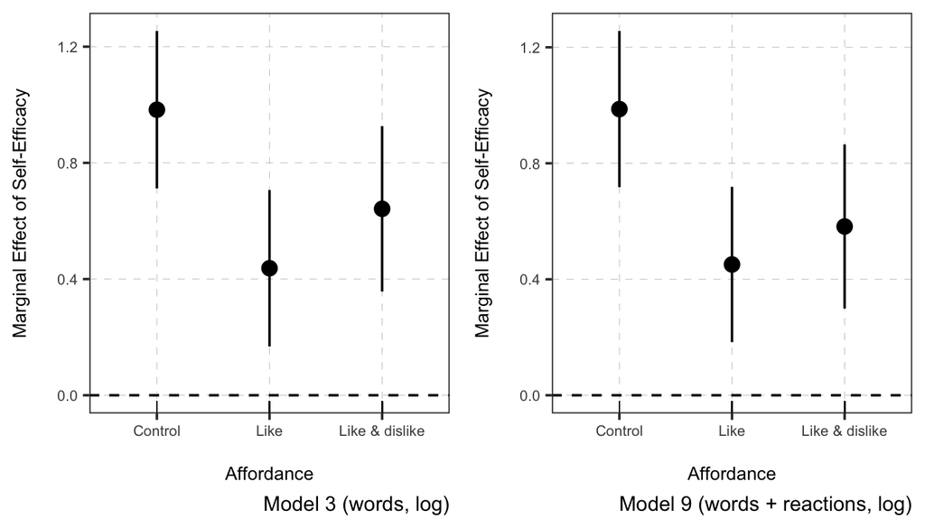

Figure 1: Marginal Effects of Self-Efficacy on Communication

```r
# common theme for both plots
me_theme <- theme_bw(base_size = 14) +
  theme(
    panel.grid.major = element_line(
      linetype = "dashed",
      color = "gray80",
      linewidth = .2
    ),
    panel.grid.minor = element_blank(),
    axis.text.x  = element_text(size = 8),
    axis.text.y  = element_text(size = 8),
    axis.title.x = element_text(size = 10, margin = margin(t = 15)),
    axis.title.y = element_text(size = 10, margin = margin(r = 15)),
    legend.title = element_text(size = 10),
    legend.position = "bottom"
  )

# plot A: marginal effect of self-efficacy per condition, outcome words (log)
marg_A <- plot_slopes(
  words_log_ols3_se,
  variables = "self_eff",
  condition = "version",
  conf_level = 0.95,
) +
  geom_rug(
    data = data,
    mapping = aes(x = version),
    sides = "b",
    inherit.aes = FALSE,
    colour = "black",
    alpha = 0.6,
    size = 0.3,
    length = grid::unit(0.03, "npc")
  ) +
  geom_hline(yintercept = 0, linetype = "dashed") +
  me_theme +
  labs(
    x = "Affordance",
    y = "Marginal Effect of Self-Efficacy",
    caption = "Model 3 (words, log)"
  )

# plot B: same for words + reactions (log)
marg_B <- plot_slopes(
  words_react_log_ols3_se,
  variables = "self_eff",
  condition = "version",
  conf_level = 0.95
) +
  geom_rug(
    data = data,
    mapping = aes(x = version),
    sides = "b",
    inherit.aes = FALSE,
    colour = "black",
    alpha = 0.6,
    size = 0.3,
    length = grid::unit(0.03, "npc")
  ) +
  geom_hline(yintercept = 0, linetype = "dashed") +
  me_theme +
  labs(
    x = "Affordance",
    y = "Marginal Effect of Self-Efficacy",
    caption = "Model 9 (words + reactions, log)"
  )

ggarrange(
  marg_A, marg_B,
  ncol = 2, nrow = 1,
  common.legend = TRUE,
  legend = "bottom"
)
```

In both models, the effect of self-efficacy is significant and positive in all three conditions (none of the confidence intervals includes zero). With like buttons, however, the effect is only about half as large as in the control condition. Figure 2 shows the same pattern as predicted values: With increasing self-efficacy, the number of words increases more strongly in the control condition than with like buttons.

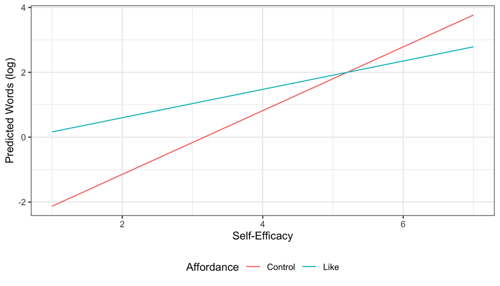

Figure 2: Predicted Values for Words (log), Model 3

```r
# predict words (log) across self-efficacy, holding the controls constant
new_vals <- expand.grid(
  self_eff = seq(1, 7, by = 0.25),
  version = c("Control", "Like", "Like & dislike"),
  male = Mode(data$male, na.rm = T),
  age = mean(data$age, na.rm = T),
  edu_fac = Mode(data$edu_fac, na.rm = T)
)

pred <- new_vals |>
  mutate(yhat = predict(words_log_ols3_se, new_vals))

pred |>
  filter(version != "Like & dislike") |>
  ggplot(aes(x = self_eff, y = yhat, color = version)) +
  geom_line() +
  theme_bw() +
  theme(
    legend.position = "bottom",
  ) +
  labs(x = "Self-Efficacy", y = "Predicted Words (log)",
    color = "Affordance")
```

### Privacy Concerns

Does privacy concerns predict how much participants wrote, and does this depend on the popularity cues? First, the OLS regressions with the log-transformed number of words.

```r
words_log_ols1_pc <- glm(words_log ~
    pri_con + version,
    data = data,
    family = "gaussian"
    )

words_log_ols2_pc <- glm(words_log ~
    pri_con * version,
    data = data,
    family = "gaussian"
    )

words_log_ols3_pc <- glm(words_log ~
    pri_con * version +
    male +
    age +
    edu_fac,
    data = data,
    family = "gaussian"
    )
```

Second, the negative binomial regressions with the raw number of words.

```r
words_nb1_pc <- glm.nb(words ~
    pri_con + version,
    data = data
    )

words_nb2_pc <- glm.nb(words ~
    pri_con * version,
    data = data
    )

words_nb3_pc <- glm.nb(words ~
    pri_con * version +
    male +
    age +
    edu_fac,
    data = data
    )
```

Table 4 shows the results.

```r
htmlreg(
  list(words_log_ols1_pc,
       words_log_ols2_pc,
       words_log_ols3_pc,
       words_nb1_pc,
       words_nb2_pc,
       words_nb3_pc
       ),
  custom.model.names = c(
    "Model 13",
    "Model 14",
    "Model 15",
    "Model 16",
    "Model 17",
    "Model 18"
    ),
  custom.header = list(
  "DV: Words (log)" = 1:3, "DV: Words" = 4:6
  ),
  custom.coef.map = list(
    "pri_con" = "Privacy Concerns",
    "versionLike" = "Like Button",
    "versionLike & dislike" = "Like Dislike Buttons",
    "male" = "Male",
    "age" = "Age",
    "pri_con:versionLike" = "Privacy Concerns x Like",
    "pri_con:versionLike & dislike" = "Privacy Concerns x Like Dislike",
    "(Intercept)" = "Constant"
  ),
  custom.gof.rows = list(
    "Estimator" = c("OLS", "OLS", "OLS", "NegBin", "NegBin", "NegBin"),
    "Controls (gender, age, education)" = c("No", "No", "Yes", "No", "No", "Yes")
    ),
  digits = 2,
  single.row = FALSE,
  caption.above = TRUE,
  table = FALSE
)
```

Statistical models

|  | DV: Words (log) Model 13 | DV: Words (log) Model 14 | DV: Words (log) Model 15 | DV: Words Model 16 | DV: Words Model 17 | DV: Words Model 18 |
| --- | --- | --- | --- | --- | --- | --- |
| Privacy Concerns | -0.21*** | -0.23* | -0.24* | -0.21* | -0.32* | -0.32* |
|  | (0.06) | (0.11) | (0.11) | (0.09) | (0.16) | (0.16) |
| Like Button | -0.15 | -0.36 | -0.21 | -0.31 | -1.05 | -0.91 |
|  | (0.23) | (0.54) | (0.54) | (0.34) | (0.78) | (0.77) |
| Like Dislike Buttons | -0.37 | -0.31 | -0.34 | -0.56 | -0.62 | -0.66 |
|  | (0.24) | (0.55) | (0.55) | (0.35) | (0.80) | (0.79) |
| Male |  |  | 0.02 |  |  | 0.07 |
|  |  |  | (0.20) |  |  | (0.28) |
| Age |  |  | 0.00 |  |  | -0.00 |
|  |  |  | (0.01) |  |  | (0.01) |
| Privacy Concerns x Like |  | 0.07 | 0.04 |  | 0.23 | 0.25 |
|  |  | (0.15) | (0.15) |  | (0.22) | (0.22) |
| Privacy Concerns x Like Dislike |  | -0.02 | 0.01 |  | 0.02 | 0.06 |
|  |  | (0.15) | (0.15) |  | (0.22) | (0.22) |
| Constant | 2.69*** | 2.75*** | 2.85*** | 5.23*** | 5.56*** | 5.55*** |
|  | (0.25) | (0.39) | (0.53) | (0.37) | (0.57) | (0.76) |
| Estimator | OLS | OLS | OLS | NegBin | NegBin | NegBin |
| Controls (gender, age, education) | No | No | Yes | No | No | Yes |
| AIC | 2517.79 | 2521.42 | 2516.79 | 3744.82 | 3747.37 | 3736.96 |
| BIC | 2539.42 | 2551.70 | 2585.98 | 3766.45 | 3777.66 | 3806.15 |
| Log Likelihood | -1253.89 | -1253.71 | -1242.39 | -1867.41 | -1866.69 | -1852.48 |
| Deviance | 2905.83 | 2903.93 | 2805.98 | 444.27 | 444.31 | 443.03 |
| Num. obs. | 559 | 559 | 558 | 559 | 559 | 558 |

***p < 0.001; **p < 0.01; *p < 0.05

Table 4: Effect of Privacy Concerns on Communication Conditional on Affordances

Privacy concerns were significantly and negatively related to communication in all six models. None of the interactions with the popularity cues was significant.

We repeat the models with words + reactions as outcome. First, the OLS regressions with the log-transformed outcome.

```r
words_react_log_ols1_pc <- glm(words_react_log ~
    pri_con + version,
    data = data,
    family = "gaussian"
    )

words_react_log_ols2_pc <- glm(words_react_log ~
    pri_con * version,
    data = data,
    family = "gaussian"
    )

words_react_log_ols3_pc <- glm(words_react_log ~
    pri_con * version +
    male +
    age +
    edu_fac,
    data = data,
    family = "gaussian"
    )
```

Second, the negative binomial regressions with the raw outcome.

```r
words_react_nb1_pc <- glm.nb(words_react ~
    pri_con + version,
    data = data
    )

words_react_nb2_pc <- glm.nb(words_react ~
    pri_con * version,
    data = data
    )

words_react_nb3_pc <- glm.nb(words_react ~
    pri_con * version +
    male +
    age +
    edu_fac,
    data = data
    )
```

Table 5 shows the results.

```r
htmlreg(
  list(words_react_log_ols1_pc,
       words_react_log_ols2_pc,
       words_react_log_ols3_pc,
       words_react_nb1_pc,
       words_react_nb2_pc,
       words_react_nb3_pc
       ),
  custom.model.names = c(
    "Model 19",
    "Model 20",
    "Model 21",
    "Model 22",
    "Model 23",
    "Model 24"
    ),
  custom.header = list(
  "DV: Words + Reactions (log)" = 1:3, "DV: Words + Reactions" = 4:6
  ),
  custom.coef.map = list(
    "pri_con" = "Privacy Concerns",
    "versionLike" = "Like Button",
    "versionLike & dislike" = "Like Dislike Buttons",
    "male" = "Male",
    "age" = "Age",
    "pri_con:versionLike" = "Privacy Concerns x Like",
    "pri_con:versionLike & dislike" = "Privacy Concerns x Like Dislike",
    "(Intercept)" = "Constant"
  ),
  custom.gof.rows = list(
    "Estimator" = c("OLS", "OLS", "OLS", "NegBin", "NegBin", "NegBin"),
    "Controls (gender, age, education)" = c("No", "No", "Yes", "No", "No", "Yes")
    ),
  digits = 2,
  single.row = FALSE,
  caption.above = TRUE,
  table = FALSE
)
```

Statistical models

|  | DV: Words + Reactions (log) Model 19 | DV: Words + Reactions (log) Model 20 | DV: Words + Reactions (log) Model 21 | DV: Words + Reactions Model 22 | DV: Words + Reactions Model 23 | DV: Words + Reactions Model 24 |
| --- | --- | --- | --- | --- | --- | --- |
| Privacy Concerns | -0.22*** | -0.23* | -0.25* | -0.21** | -0.32* | -0.33* |
|  | (0.06) | (0.11) | (0.11) | (0.08) | (0.15) | (0.15) |
| Like Button | -0.01 | -0.16 | -0.03 | -0.29 | -1.03 | -0.81 |
|  | (0.23) | (0.53) | (0.53) | (0.32) | (0.72) | (0.71) |
| Like Dislike Buttons | -0.24 | -0.19 | -0.21 | -0.54 | -0.60 | -0.50 |
|  | (0.24) | (0.54) | (0.54) | (0.32) | (0.74) | (0.73) |
| Male |  |  | -0.02 |  |  | -0.02 |
|  |  |  | (0.20) |  |  | (0.26) |
| Age |  |  | 0.00 |  |  | -0.00 |
|  |  |  | (0.01) |  |  | (0.01) |
| Privacy Concerns x Like |  | 0.05 | 0.02 |  | 0.23 | 0.21 |
|  |  | (0.15) | (0.15) |  | (0.20) | (0.20) |
| Privacy Concerns x Like Dislike |  | -0.01 | 0.01 |  | 0.02 | 0.03 |
|  |  | (0.15) | (0.15) |  | (0.20) | (0.20) |
| Constant | 2.71*** | 2.75*** | 2.86*** | 5.23*** | 5.56*** | 5.63*** |
|  | (0.25) | (0.39) | (0.52) | (0.34) | (0.52) | (0.70) |
| Estimator | OLS | OLS | OLS | NegBin | NegBin | NegBin |
| Controls (gender, age, education) | No | No | Yes | No | No | Yes |
| AIC | 2504.10 | 2507.91 | 2507.36 | 3943.07 | 3945.41 | 3932.78 |
| BIC | 2525.73 | 2538.19 | 2576.55 | 3964.70 | 3975.70 | 4001.97 |
| Log Likelihood | -1247.05 | -1246.95 | -1237.68 | -1966.53 | -1965.71 | -1950.39 |
| Deviance | 2835.57 | 2834.58 | 2758.97 | 482.38 | 482.40 | 481.04 |
| Num. obs. | 559 | 559 | 558 | 559 | 559 | 558 |

***p < 0.001; **p < 0.01; *p < 0.05

Table 5: Effect of Privacy Concerns on Communication (incl. Reactions) Conditional on Affordances

The results for words + reactions are the same: Privacy concerns were significantly and negatively related to communication in all six models (Models 19 to 24), and none of the interactions with the popularity cues was significant.

### Gratifications

Does gratifications predict how much participants wrote, and does this depend on the popularity cues? First, the OLS regressions with the log-transformed number of words.

```r
words_log_ols1_gg <- glm(words_log ~
    grats_gen + version,
    data = data,
    family = "gaussian"
    )

words_log_ols2_gg <- glm(words_log ~
    grats_gen * version,
    data = data,
    family = "gaussian"
    )

words_log_ols3_gg <- glm(words_log ~
    grats_gen * version +
    male +
    age +
    edu_fac,
    data = data,
    family = "gaussian"
    )
```

Second, the negative binomial regressions with the raw number of words.

```r
words_nb1_gg <- glm.nb(words ~
    grats_gen + version,
    data = data
    )

words_nb2_gg <- glm.nb(words ~
    grats_gen * version,
    data = data
    )

words_nb3_gg <- glm.nb(words ~
    grats_gen * version +
    male +
    age +
    edu_fac,
    data = data
    )
```

Table 6 shows the results.

```r
htmlreg(
  list(words_log_ols1_gg,
       words_log_ols2_gg,
       words_log_ols3_gg,
       words_nb1_gg,
       words_nb2_gg,
       words_nb3_gg
       ),
  custom.model.names = c(
    "Model 25",
    "Model 26",
    "Model 27",
    "Model 28",
    "Model 29",
    "Model 30"
    ),
  custom.header = list(
  "DV: Words (log)" = 1:3, "DV: Words" = 4:6
  ),
  custom.coef.map = list(
    "grats_gen" = "Gratifications",
    "versionLike" = "Like Button",
    "versionLike & dislike" = "Like Dislike Buttons",
    "male" = "Male",
    "age" = "Age",
    "grats_gen:versionLike" = "Gratifications x Like",
    "grats_gen:versionLike & dislike" = "Gratifications x Like Dislike",
    "(Intercept)" = "Constant"
  ),
  custom.gof.rows = list(
    "Estimator" = c("OLS", "OLS", "OLS", "NegBin", "NegBin", "NegBin"),
    "Controls (gender, age, education)" = c("No", "No", "Yes", "No", "No", "Yes")
    ),
  digits = 2,
  single.row = FALSE,
  caption.above = TRUE,
  table = FALSE
)
```

Statistical models

|  | DV: Words (log) Model 25 | DV: Words (log) Model 26 | DV: Words (log) Model 27 | DV: Words Model 28 | DV: Words Model 29 | DV: Words Model 30 |
| --- | --- | --- | --- | --- | --- | --- |
| Gratifications | 0.19* | 0.31* | 0.31* | 0.27* | 0.37 | 0.26 |
|  | (0.08) | (0.14) | (0.14) | (0.12) | (0.21) | (0.21) |
| Like Button | -0.12 | 0.50 | 0.31 | -0.31 | 0.53 | -0.20 |
|  | (0.24) | (0.97) | (0.97) | (0.34) | (1.40) | (1.38) |
| Like Dislike Buttons | -0.36 | 0.76 | 0.67 | -0.51 | -0.13 | -0.56 |
|  | (0.24) | (1.00) | (0.99) | (0.35) | (1.44) | (1.43) |
| Male |  |  | 0.07 |  |  | 0.00 |
|  |  |  | (0.20) |  |  | (0.28) |
| Age |  |  | 0.00 |  |  | -0.00 |
|  |  |  | (0.01) |  |  | (0.01) |
| Gratifications x Like |  | -0.13 | -0.08 |  | -0.17 | -0.00 |
|  |  | (0.20) | (0.20) |  | (0.28) | (0.28) |
| Gratifications x Like Dislike |  | -0.23 | -0.21 |  | -0.07 | 0.02 |
|  |  | (0.20) | (0.20) |  | (0.29) | (0.29) |
| Constant | 1.07* | 0.48 | 0.51 | 3.22*** | 2.73** | 3.37** |
|  | (0.43) | (0.72) | (0.78) | (0.62) | (1.05) | (1.12) |
| Estimator | OLS | OLS | OLS | NegBin | NegBin | NegBin |
| Controls (gender, age, education) | No | No | Yes | No | No | Yes |
| AIC | 2524.28 | 2526.93 | 2522.31 | 3744.65 | 3748.28 | 3739.16 |
| BIC | 2545.91 | 2557.21 | 2591.50 | 3766.29 | 3778.56 | 3808.35 |
| Log Likelihood | -1257.14 | -1256.46 | -1245.16 | -1867.33 | -1867.14 | -1853.58 |
| Deviance | 2939.80 | 2932.67 | 2833.90 | 444.27 | 444.28 | 443.03 |
| Num. obs. | 559 | 559 | 558 | 559 | 559 | 558 |

***p < 0.001; **p < 0.01; *p < 0.05

Table 6: Effect of Gratifications on Communication Conditional on Affordances

Gratifications were significantly and positively related to communication in Models 25 to 28, but not in the two negative binomial models with interaction (Models 29 and 30). None of the interactions with the popularity cues was significant.

We repeat the models with words + reactions as outcome. First, the OLS regressions with the log-transformed outcome.

```r
words_react_log_ols1_gg <- glm(words_react_log ~
    grats_gen + version,
    data = data,
    family = "gaussian"
    )

words_react_log_ols2_gg <- glm(words_react_log ~
    grats_gen * version,
    data = data,
    family = "gaussian"
    )

words_react_log_ols3_gg <- glm(words_react_log ~
    grats_gen * version +
    male +
    age +
    edu_fac,
    data = data,
    family = "gaussian"
    )
```

Second, the negative binomial regressions with the raw outcome.

```r
words_react_nb1_gg <- glm.nb(words_react ~
    grats_gen + version,
    data = data
    )

words_react_nb2_gg <- glm.nb(words_react ~
    grats_gen * version,
    data = data
    )

words_react_nb3_gg <- glm.nb(words_react ~
    grats_gen * version +
    male +
    age +
    edu_fac,
    data = data
    )
```

Table 7 shows the results.

```r
htmlreg(
  list(words_react_log_ols1_gg,
       words_react_log_ols2_gg,
       words_react_log_ols3_gg,
       words_react_nb1_gg,
       words_react_nb2_gg,
       words_react_nb3_gg
       ),
  custom.model.names = c(
    "Model 31",
    "Model 32",
    "Model 33",
    "Model 34",
    "Model 35",
    "Model 36"
    ),
  custom.header = list(
  "DV: Words + Reactions (log)" = 1:3, "DV: Words + Reactions" = 4:6
  ),
  custom.coef.map = list(
    "grats_gen" = "Gratifications",
    "versionLike" = "Like Button",
    "versionLike & dislike" = "Like Dislike Buttons",
    "male" = "Male",
    "age" = "Age",
    "grats_gen:versionLike" = "Gratifications x Like",
    "grats_gen:versionLike & dislike" = "Gratifications x Like Dislike",
    "(Intercept)" = "Constant"
  ),
  custom.gof.rows = list(
    "Estimator" = c("OLS", "OLS", "OLS", "NegBin", "NegBin", "NegBin"),
    "Controls (gender, age, education)" = c("No", "No", "Yes", "No", "No", "Yes")
    ),
  digits = 2,
  single.row = FALSE,
  caption.above = TRUE,
  table = FALSE
)
```

Statistical models

|  | DV: Words + Reactions (log) Model 31 | DV: Words + Reactions (log) Model 32 | DV: Words + Reactions (log) Model 33 | DV: Words + Reactions Model 34 | DV: Words + Reactions Model 35 | DV: Words + Reactions Model 36 |
| --- | --- | --- | --- | --- | --- | --- |
| Gratifications | 0.22** | 0.31* | 0.31* | 0.27* | 0.37 | 0.26 |
|  | (0.08) | (0.14) | (0.14) | (0.11) | (0.19) | (0.19) |
| Like Button | 0.02 | 0.49 | 0.33 | -0.29 | 0.53 | -0.23 |
|  | (0.23) | (0.95) | (0.96) | (0.32) | (1.30) | (1.28) |
| Like Dislike Buttons | -0.23 | 0.72 | 0.66 | -0.48 | -0.11 | -0.62 |
|  | (0.24) | (0.98) | (0.99) | (0.32) | (1.34) | (1.32) |
| Male |  |  | 0.03 |  |  | 0.02 |
|  |  |  | (0.20) |  |  | (0.26) |
| Age |  |  | 0.00 |  |  | -0.00 |
|  |  |  | (0.01) |  |  | (0.01) |
| Gratifications x Like |  | -0.10 | -0.05 |  | -0.17 | 0.00 |
|  |  | (0.19) | (0.19) |  | (0.26) | (0.26) |
| Gratifications x Like Dislike |  | -0.20 | -0.18 |  | -0.07 | 0.04 |
|  |  | (0.20) | (0.20) |  | (0.27) | (0.27) |
| Constant | 0.96* | 0.48 | 0.51 | 3.21*** | 2.73** | 3.39** |
|  | (0.42) | (0.71) | (0.78) | (0.57) | (0.97) | (1.04) |
| Estimator | OLS | OLS | OLS | NegBin | NegBin | NegBin |
| Controls (gender, age, education) | No | No | Yes | No | No | Yes |
| AIC | 2510.07 | 2513.07 | 2512.71 | 3942.81 | 3946.39 | 3936.04 |
| BIC | 2531.70 | 2543.35 | 2581.90 | 3964.44 | 3976.67 | 4005.23 |
| Log Likelihood | -1250.04 | -1249.53 | -1240.35 | -1966.41 | -1966.19 | -1952.02 |
| Deviance | 2865.99 | 2860.87 | 2785.54 | 482.38 | 482.39 | 481.02 |
| Num. obs. | 559 | 559 | 558 | 559 | 559 | 558 |

***p < 0.001; **p < 0.01; *p < 0.05

Table 7: Effect of Gratifications on Communication (incl. Reactions) Conditional on Affordances

The results for words + reactions are the same: Gratifications were significantly and positively related to communication in Models 31 to 34, but not in the two negative binomial models with interaction (Models 35 and 36). None of the interactions with the popularity cues was significant.

### Privacy Deliberation

Does privacy deliberation predict how much participants wrote, and does this depend on the popularity cues? First, the OLS regressions with the log-transformed number of words.

```r
words_log_ols1_pd <- glm(words_log ~
    pri_delib + version,
    data = data,
    family = "gaussian"
    )

words_log_ols2_pd <- glm(words_log ~
    pri_delib * version,
    data = data,
    family = "gaussian"
    )

words_log_ols3_pd <- glm(words_log ~
    pri_delib * version +
    male +
    age +
    edu_fac,
    data = data,
    family = "gaussian"
    )
```

Second, the negative binomial regressions with the raw number of words.

```r
words_nb1_pd <- glm.nb(words ~
    pri_delib + version,
    data = data
    )

words_nb2_pd <- glm.nb(words ~
    pri_delib * version,
    data = data
    )

words_nb3_pd <- glm.nb(words ~
    pri_delib * version +
    male +
    age +
    edu_fac,
    data = data
    )
```

Table 8 shows the results.

```r
htmlreg(
  list(words_log_ols1_pd,
       words_log_ols2_pd,
       words_log_ols3_pd,
       words_nb1_pd,
       words_nb2_pd,
       words_nb3_pd
       ),
  custom.model.names = c(
    "Model 37",
    "Model 38",
    "Model 39",
    "Model 40",
    "Model 41",
    "Model 42"
    ),
  custom.header = list(
  "DV: Words (log)" = 1:3, "DV: Words" = 4:6
  ),
  custom.coef.map = list(
    "pri_delib" = "Privacy Deliberation",
    "versionLike" = "Like Button",
    "versionLike & dislike" = "Like Dislike Buttons",
    "male" = "Male",
    "age" = "Age",
    "pri_delib:versionLike" = "Privacy Deliberation x Like",
    "pri_delib:versionLike & dislike" = "Privacy Deliberation x Like Dislike",
    "(Intercept)" = "Constant"
  ),
  custom.gof.rows = list(
    "Estimator" = c("OLS", "OLS", "OLS", "NegBin", "NegBin", "NegBin"),
    "Controls (gender, age, education)" = c("No", "No", "Yes", "No", "No", "Yes")
    ),
  digits = 2,
  single.row = FALSE,
  caption.above = TRUE,
  table = FALSE
)
```

Statistical models

|  | DV: Words (log) Model 37 | DV: Words (log) Model 38 | DV: Words (log) Model 39 | DV: Words Model 40 | DV: Words Model 41 | DV: Words Model 42 |
| --- | --- | --- | --- | --- | --- | --- |
| Privacy Deliberation | -0.35*** | -0.41** | -0.43*** | -0.36** | -0.44* | -0.41* |
|  | (0.07) | (0.12) | (0.13) | (0.11) | (0.18) | (0.18) |
| Like Button | -0.14 | -1.24 | -1.19 | -0.25 | -1.34 | -0.95 |
|  | (0.23) | (0.75) | (0.76) | (0.34) | (1.09) | (1.09) |
| Like Dislike Buttons | -0.42 | -0.07 | -0.15 | -0.63 | 0.27 | 0.55 |
|  | (0.24) | (0.75) | (0.75) | (0.35) | (1.09) | (1.08) |
| Male |  |  | -0.01 |  |  | -0.05 |
|  |  |  | (0.20) |  |  | (0.28) |
| Age |  |  | 0.00 |  |  | -0.01 |
|  |  |  | (0.01) |  |  | (0.01) |
| Privacy Deliberation x Like |  | 0.28 | 0.27 |  | 0.27 | 0.20 |
|  |  | (0.18) | (0.18) |  | (0.26) | (0.26) |
| Privacy Deliberation x Like Dislike |  | -0.09 | -0.06 |  | -0.24 | -0.32 |
|  |  | (0.18) | (0.18) |  | (0.27) | (0.26) |
| Constant | 3.39*** | 3.63*** | 3.89*** | 5.90*** | 6.21*** | 6.51*** |
|  | (0.34) | (0.52) | (0.64) | (0.49) | (0.75) | (0.91) |
| Estimator | OLS | OLS | OLS | NegBin | NegBin | NegBin |
| Controls (gender, age, education) | No | No | Yes | No | No | Yes |
| AIC | 2508.51 | 2508.19 | 2504.30 | 3740.11 | 3740.85 | 3729.08 |
| BIC | 2530.14 | 2538.47 | 2573.49 | 3761.74 | 3771.13 | 3798.27 |
| Log Likelihood | -1249.25 | -1247.09 | -1236.15 | -1865.05 | -1863.42 | -1848.54 |
| Deviance | 2857.99 | 2835.99 | 2743.90 | 444.40 | 444.49 | 443.23 |
| Num. obs. | 559 | 559 | 558 | 559 | 559 | 558 |

***p < 0.001; **p < 0.01; *p < 0.05

Table 8: Effect of Privacy Deliberation on Communication Conditional on Affordances

Privacy deliberation was significantly and negatively related to communication in all six models. None of the interactions with the popularity cues was significant.

We repeat the models with words + reactions as outcome. First, the OLS regressions with the log-transformed outcome.

```r
words_react_log_ols1_pd <- glm(words_react_log ~
    pri_delib + version,
    data = data,
    family = "gaussian"
    )

words_react_log_ols2_pd <- glm(words_react_log ~
    pri_delib * version,
    data = data,
    family = "gaussian"
    )

words_react_log_ols3_pd <- glm(words_react_log ~
    pri_delib * version +
    male +
    age +
    edu_fac,
    data = data,
    family = "gaussian"
    )
```

Second, the negative binomial regressions with the raw outcome.

```r
words_react_nb1_pd <- glm.nb(words_react ~
    pri_delib + version,
    data = data
    )

words_react_nb2_pd <- glm.nb(words_react ~
    pri_delib * version,
    data = data
    )

words_react_nb3_pd <- glm.nb(words_react ~
    pri_delib * version +
    male +
    age +
    edu_fac,
    data = data
    )
```

Table 9 shows the results.

```r
htmlreg(
  list(words_react_log_ols1_pd,
       words_react_log_ols2_pd,
       words_react_log_ols3_pd,
       words_react_nb1_pd,
       words_react_nb2_pd,
       words_react_nb3_pd
       ),
  custom.model.names = c(
    "Model 43",
    "Model 44",
    "Model 45",
    "Model 46",
    "Model 47",
    "Model 48"
    ),
  custom.header = list(
  "DV: Words + Reactions (log)" = 1:3, "DV: Words + Reactions" = 4:6
  ),
  custom.coef.map = list(
    "pri_delib" = "Privacy Deliberation",
    "versionLike" = "Like Button",
    "versionLike & dislike" = "Like Dislike Buttons",
    "male" = "Male",
    "age" = "Age",
    "pri_delib:versionLike" = "Privacy Deliberation x Like",
    "pri_delib:versionLike & dislike" = "Privacy Deliberation x Like Dislike",
    "(Intercept)" = "Constant"
  ),
  custom.gof.rows = list(
    "Estimator" = c("OLS", "OLS", "OLS", "NegBin", "NegBin", "NegBin"),
    "Controls (gender, age, education)" = c("No", "No", "Yes", "No", "No", "Yes")
    ),
  digits = 2,
  single.row = FALSE,
  caption.above = TRUE,
  table = FALSE
)
```

Statistical models

|  | DV: Words + Reactions (log) Model 43 | DV: Words + Reactions (log) Model 44 | DV: Words + Reactions (log) Model 45 | DV: Words + Reactions Model 46 | DV: Words + Reactions Model 47 | DV: Words + Reactions Model 48 |
| --- | --- | --- | --- | --- | --- | --- |
| Privacy Deliberation | -0.35*** | -0.41*** | -0.43*** | -0.35*** | -0.44** | -0.41* |
|  | (0.07) | (0.12) | (0.12) | (0.10) | (0.17) | (0.17) |
| Like Button | -0.01 | -1.09 | -1.02 | -0.23 | -1.34 | -0.98 |
|  | (0.23) | (0.74) | (0.75) | (0.31) | (1.01) | (1.01) |
| Like Dislike Buttons | -0.29 | 0.09 | 0.04 | -0.60 | 0.25 | 0.59 |
|  | (0.23) | (0.74) | (0.74) | (0.32) | (1.01) | (1.00) |
| Male |  |  | -0.05 |  |  | -0.05 |
|  |  |  | (0.19) |  |  | (0.26) |
| Age |  |  | -0.00 |  |  | -0.01 |
|  |  |  | (0.01) |  |  | (0.01) |
| Privacy Deliberation x Like |  | 0.27 | 0.27 |  | 0.27 | 0.21 |
|  |  | (0.18) | (0.18) |  | (0.24) | (0.24) |
| Privacy Deliberation x Like Dislike |  | -0.10 | -0.08 |  | -0.23 | -0.32 |
|  |  | (0.18) | (0.18) |  | (0.25) | (0.24) |
| Constant | 3.40*** | 3.63*** | 3.90*** | 5.88*** | 6.21*** | 6.51*** |
|  | (0.33) | (0.51) | (0.63) | (0.46) | (0.70) | (0.84) |
| Estimator | OLS | OLS | OLS | NegBin | NegBin | NegBin |
| Controls (gender, age, education) | No | No | Yes | No | No | Yes |
| AIC | 2494.94 | 2494.47 | 2494.79 | 3937.86 | 3938.13 | 3924.95 |
| BIC | 2516.57 | 2524.75 | 2563.98 | 3959.49 | 3968.41 | 3994.14 |
| Log Likelihood | -1242.47 | -1240.24 | -1231.40 | -1963.93 | -1962.07 | -1946.48 |
| Deviance | 2789.46 | 2767.25 | 2697.52 | 482.46 | 482.51 | 481.13 |
| Num. obs. | 559 | 559 | 558 | 559 | 559 | 558 |

***p < 0.001; **p < 0.01; *p < 0.05

Table 9: Effect of Privacy Deliberation on Communication (incl. Reactions) Conditional on Affordances

The results for words + reactions are the same: Privacy deliberation was significantly and negatively related to communication in all six models (Models 43 to 48), and none of the interactions with the popularity cues was significant.

### Trust

Does general trust predict how much participants wrote, and does this depend on the popularity cues? First, the OLS regressions with the log-transformed number of words.

```r
words_log_ols1_tg <- glm(words_log ~
    trust_gen + version,
    data = data,
    family = "gaussian"
    )

words_log_ols2_tg <- glm(words_log ~
    trust_gen * version,
    data = data,
    family = "gaussian"
    )

words_log_ols3_tg <- glm(words_log ~
    trust_gen * version +
    male +
    age +
    edu_fac,
    data = data,
    family = "gaussian"
    )
```

Second, the negative binomial regressions with the raw number of words.

```r
words_nb1_tg <- glm.nb(words ~
    trust_gen + version,
    data = data
    )

words_nb2_tg <- glm.nb(words ~
    trust_gen * version,
    data = data
    )

words_nb3_tg <- glm.nb(words ~
    trust_gen * version +
    male +
    age +
    edu_fac,
    data = data
    )
```

Table 10 shows the results.

```r
htmlreg(
  list(words_log_ols1_tg,
       words_log_ols2_tg,
       words_log_ols3_tg,
       words_nb1_tg,
       words_nb2_tg,
       words_nb3_tg
       ),
  custom.model.names = c(
    "Model 49",
    "Model 50",
    "Model 51",
    "Model 52",
    "Model 53",
    "Model 54"
    ),
  custom.header = list(
  "DV: Words (log)" = 1:3, "DV: Words" = 4:6
  ),
  custom.coef.map = list(
    "trust_gen" = "Trust",
    "versionLike" = "Like Button",
    "versionLike & dislike" = "Like Dislike Buttons",
    "male" = "Male",
    "age" = "Age",
    "trust_gen:versionLike" = "Trust x Like",
    "trust_gen:versionLike & dislike" = "Trust x Like Dislike",
    "(Intercept)" = "Constant"
  ),
  custom.gof.rows = list(
    "Estimator" = c("OLS", "OLS", "OLS", "NegBin", "NegBin", "NegBin"),
    "Controls (gender, age, education)" = c("No", "No", "Yes", "No", "No", "Yes")
    ),
  digits = 2,
  single.row = FALSE,
  caption.above = TRUE,
  table = FALSE
)
```

Statistical models

|  | DV: Words (log) Model 49 | DV: Words (log) Model 50 | DV: Words (log) Model 51 | DV: Words Model 52 | DV: Words Model 53 | DV: Words Model 54 |
| --- | --- | --- | --- | --- | --- | --- |
| Trust | 0.32*** | 0.47** | 0.48** | 0.26 | 0.54* | 0.46* |
|  | (0.09) | (0.16) | (0.16) | (0.14) | (0.24) | (0.23) |
| Like Button | -0.10 | 0.98 | 0.94 | -0.27 | 2.36 | 2.57 |
|  | (0.23) | (1.22) | (1.22) | (0.34) | (1.78) | (1.76) |
| Like Dislike Buttons | -0.37 | 0.94 | 1.01 | -0.55 | 0.28 | -0.03 |
|  | (0.24) | (1.22) | (1.22) | (0.35) | (1.78) | (1.76) |
| Male |  |  | 0.05 |  |  | -0.11 |
|  |  |  | (0.20) |  |  | (0.28) |
| Age |  |  | 0.00 |  |  | 0.00 |
|  |  |  | (0.01) |  |  | (0.01) |
| Trust x Like |  | -0.21 | -0.19 |  | -0.51 | -0.52 |
|  |  | (0.23) | (0.23) |  | (0.33) | (0.33) |
| Trust x Like Dislike |  | -0.25 | -0.25 |  | -0.15 | -0.09 |
|  |  | (0.23) | (0.23) |  | (0.33) | (0.33) |
| Constant | 0.34 | -0.47 | -0.60 | 3.17*** | 1.72 | 2.12 |
|  | (0.52) | (0.88) | (0.94) | (0.76) | (1.28) | (1.35) |
| Estimator | OLS | OLS | OLS | NegBin | NegBin | NegBin |
| Controls (gender, age, education) | No | No | Yes | No | No | Yes |
| AIC | 2518.66 | 2521.29 | 2516.75 | 3747.23 | 3749.35 | 3739.06 |
| BIC | 2540.29 | 2551.57 | 2585.94 | 3768.86 | 3779.64 | 3808.25 |
| Log Likelihood | -1254.33 | -1253.64 | -1242.38 | -1868.61 | -1867.68 | -1853.53 |
| Deviance | 2910.38 | 2903.24 | 2805.80 | 444.20 | 444.25 | 443.02 |
| Num. obs. | 559 | 559 | 558 | 559 | 559 | 558 |

***p < 0.001; **p < 0.01; *p < 0.05

Table 10: Effect of General Trust on Communication Conditional on Affordances

General trust was significantly and positively related to communication in Models 49 to 51 and 53 to 54, but not in Model 52 (negative binomial model without interaction). None of the interactions with the popularity cues was significant.

We repeat the models with words + reactions as outcome. First, the OLS regressions with the log-transformed outcome.

```r
words_react_log_ols1_tg <- glm(words_react_log ~
    trust_gen + version,
    data = data,
    family = "gaussian"
    )

words_react_log_ols2_tg <- glm(words_react_log ~
    trust_gen * version,
    data = data,
    family = "gaussian"
    )

words_react_log_ols3_tg <- glm(words_react_log ~
    trust_gen * version +
    male +
    age +
    edu_fac,
    data = data,
    family = "gaussian"
    )
```

Second, the negative binomial regressions with the raw outcome.

```r
words_react_nb1_tg <- glm.nb(words_react ~
    trust_gen + version,
    data = data
    )

words_react_nb2_tg <- glm.nb(words_react ~
    trust_gen * version,
    data = data
    )

words_react_nb3_tg <- glm.nb(words_react ~
    trust_gen * version +
    male +
    age +
    edu_fac,
    data = data
    )
```

Table 11 shows the results.

```r
htmlreg(
  list(words_react_log_ols1_tg,
       words_react_log_ols2_tg,
       words_react_log_ols3_tg,
       words_react_nb1_tg,
       words_react_nb2_tg,
       words_react_nb3_tg
       ),
  custom.model.names = c(
    "Model 55",
    "Model 56",
    "Model 57",
    "Model 58",
    "Model 59",
    "Model 60"
    ),
  custom.header = list(
  "DV: Words + Reactions (log)" = 1:3, "DV: Words + Reactions" = 4:6
  ),
  custom.coef.map = list(
    "trust_gen" = "Trust",
    "versionLike" = "Like Button",
    "versionLike & dislike" = "Like Dislike Buttons",
    "male" = "Male",
    "age" = "Age",
    "trust_gen:versionLike" = "Trust x Like",
    "trust_gen:versionLike & dislike" = "Trust x Like Dislike",
    "(Intercept)" = "Constant"
  ),
  custom.gof.rows = list(
    "Estimator" = c("OLS", "OLS", "OLS", "NegBin", "NegBin", "NegBin"),
    "Controls (gender, age, education)" = c("No", "No", "Yes", "No", "No", "Yes")
    ),
  digits = 2,
  single.row = FALSE,
  caption.above = TRUE,
  table = FALSE
)
```

Statistical models

|  | DV: Words + Reactions (log) Model 55 | DV: Words + Reactions (log) Model 56 | DV: Words + Reactions (log) Model 57 | DV: Words + Reactions Model 58 | DV: Words + Reactions Model 59 | DV: Words + Reactions Model 60 |
| --- | --- | --- | --- | --- | --- | --- |
| Trust | 0.31*** | 0.47** | 0.48** | 0.27* | 0.53* | 0.46* |
|  | (0.09) | (0.16) | (0.16) | (0.13) | (0.22) | (0.22) |
| Like Button | 0.03 | 1.13 | 1.08 | -0.26 | 2.35 | 2.42 |
|  | (0.23) | (1.21) | (1.21) | (0.32) | (1.65) | (1.63) |
| Like Dislike Buttons | -0.25 | 1.09 | 1.18 | -0.53 | 0.31 | -0.08 |
|  | (0.24) | (1.21) | (1.22) | (0.32) | (1.65) | (1.63) |
| Male |  |  | 0.00 |  |  | -0.08 |
|  |  |  | (0.20) |  |  | (0.26) |
| Age |  |  | 0.00 |  |  | -0.00 |
|  |  |  | (0.01) |  |  | (0.01) |
| Trust x Like |  | -0.21 | -0.19 |  | -0.50 | -0.49 |
|  |  | (0.23) | (0.23) |  | (0.31) | (0.31) |
| Trust x Like Dislike |  | -0.26 | -0.26 |  | -0.15 | -0.07 |
|  |  | (0.23) | (0.23) |  | (0.31) | (0.31) |
| Constant | 0.36 | -0.47 | -0.58 | 3.16*** | 1.72 | 2.15 |
|  | (0.52) | (0.87) | (0.93) | (0.71) | (1.18) | (1.25) |
| Estimator | OLS | OLS | OLS | NegBin | NegBin | NegBin |
| Controls (gender, age, education) | No | No | Yes | No | No | Yes |
| AIC | 2506.02 | 2508.57 | 2508.61 | 3945.85 | 3947.72 | 3936.35 |
| BIC | 2527.65 | 2538.85 | 2577.80 | 3967.48 | 3978.00 | 4005.54 |
| Log Likelihood | -1248.01 | -1247.28 | -1238.31 | -1967.92 | -1966.86 | -1952.17 |
| Deviance | 2845.32 | 2837.92 | 2765.17 | 482.33 | 482.36 | 481.01 |
| Num. obs. | 559 | 559 | 558 | 559 | 559 | 558 |

***p < 0.001; **p < 0.01; *p < 0.05

Table 11: Effect of General Trust on Communication (incl. Reactions) Conditional on Affordances

For words + reactions, general trust was significantly and positively related to communication in all six models (Models 55 to 60). None of the interactions with the popularity cues was significant.

### All Predictors Combined

Finally, we include all privacy calculus variables in one model. Because the predictors are correlated, these models should be interpreted with caution (see Variance Inflation Factors). The interaction is only tested for self-efficacy, the only variable with a significant interaction above.

Here, we only report OLS regressions. The negative binomial regressions with all predictors did not converge: the outcome contains many zeros and is strongly skewed (which is also why the main analyses use hurdle models).

```r
words_log_ols1_comp <- glm(words_log ~
    self_eff +
    version +
    pri_con +
    grats_gen +
    pri_delib +
    trust_gen,
    data = data,
    family = "gaussian"
    )

words_log_ols2_comp <- glm(words_log ~
    self_eff * version +
    pri_con +
    grats_gen +
    pri_delib +
    trust_gen,
    data = data,
    family = "gaussian"
    )

words_log_ols3_comp <- glm(words_log ~
    self_eff * version +
    pri_con +
    grats_gen +
    pri_delib +
    trust_gen +
    male +
    age +
    edu_fac,
    data = data,
    family = "gaussian"
    )
```

Table 12 shows the results.

```r
htmlreg(
  list(words_log_ols1_comp,
       words_log_ols2_comp,
       words_log_ols3_comp
       ),
  custom.model.names = c(
    "Model 61",
    "Model 62",
    "Model 63"
    ),
  custom.header = list(
  "DV: Words (log)" = 1:3
  ),
  custom.coef.map = list(
    "versionLike" = "Like Button",
    "versionLike & dislike" = "Like Dislike Buttons",
    "self_eff" = "Self-Efficacy",
    "pri_con" = "Privacy Concerns",
    "grats_gen" = "Gratifications",
    "pri_delib" = "Privacy Deliberation",
    "trust_gen" = "Trust",
    "male" = "Male",
    "age" = "Age",
    "self_eff:versionLike" = "Self-Efficacy x Like",
    "self_eff:versionLike & dislike" = "Self-Efficacy x Like Dislike",
    "(Intercept)" = "Constant"
  ),
  custom.gof.rows = list(
    "Estimator" = c("OLS", "OLS", "OLS"),
    "Controls (gender, age, education)" = c("No", "No", "Yes")
    ),
  digits = 2,
  single.row = FALSE,
  caption.above = TRUE,
  table = FALSE
)
```

Statistical models

|  | DV: Words (log) Model 61 | DV: Words (log) Model 62 | DV: Words (log) Model 63 |
| --- | --- | --- | --- |
| Like Button | -0.10 | 2.23* | 2.51* |
|  | (0.22) | (1.06) | (1.06) |
| Like Dislike Buttons | -0.35 | 0.91 | 1.20 |
|  | (0.23) | (1.09) | (1.09) |
| Self-Efficacy | 0.71*** | 0.94*** | 0.93*** |
|  | (0.09) | (0.15) | (0.15) |
| Privacy Concerns | -0.04 | -0.06 | -0.07 |
|  | (0.07) | (0.07) | (0.07) |
| Gratifications | 0.04 | 0.02 | 0.04 |
|  | (0.09) | (0.09) | (0.09) |
| Privacy Deliberation | -0.25** | -0.22** | -0.22** |
|  | (0.08) | (0.08) | (0.08) |
| Trust | -0.14 | -0.14 | -0.13 |
|  | (0.12) | (0.12) | (0.12) |
| Male |  |  | -0.11 |
|  |  |  | (0.19) |
| Age |  |  | 0.00 |
|  |  |  | (0.01) |
| Self-Efficacy x Like |  | -0.44* | -0.49* |
|  |  | (0.20) | (0.20) |
| Self-Efficacy x Like Dislike |  | -0.24 | -0.28 |
|  |  | (0.20) | (0.20) |
| Constant | -0.13 | -1.35 | -1.24 |
|  | (0.70) | (0.94) | (1.02) |
| Estimator | OLS | OLS | OLS |
| Controls (gender, age, education) | No | No | Yes |
| AIC | 2444.81 | 2443.68 | 2445.20 |
| BIC | 2483.73 | 2491.25 | 2531.65 |
| Log Likelihood | -1213.40 | -1210.84 | -1202.60 |
| Deviance | 2529.06 | 2505.94 | 2447.48 |
| Num. obs. | 558 | 558 | 557 |

***p < 0.001; **p < 0.01; *p < 0.05

Table 12: Effect of Privacy Calculus on Communication Conditional on Affordances

When all variables are analyzed together, two variables remain significant in all three models (Models 61 to 63): self-efficacy (positive) and privacy deliberation (negative). Privacy concerns, gratifications, and trust are no longer significant, which is in line with the problems of multicollinearity described above. The interaction between self-efficacy and like buttons remains significant and negative (Models 62 and 63); the interaction with like & dislike buttons is not significant.

The same models with words + reactions as outcome:

```r
words_react_log_ols1_comp <- glm(words_react_log ~
    self_eff +
    version +
    pri_con +
    grats_gen +
    pri_delib +
    trust_gen,
    data = data,
    family = "gaussian"
    )

words_react_log_ols2_comp <- glm(words_react_log ~
    self_eff * version +
    pri_con +
    grats_gen +
    pri_delib +
    trust_gen,
    data = data,
    family = "gaussian"
    )

words_react_log_ols3_comp <- glm(words_react_log ~
    self_eff * version +
    pri_con +
    grats_gen +
    pri_delib +
    trust_gen +
    male +
    age +
    edu_fac,
    data = data,
    family = "gaussian"
    )
```

Table 13 shows the results.

```r
htmlreg(
  list(words_react_log_ols1_comp,
       words_react_log_ols2_comp,
       words_react_log_ols3_comp
       ),
  custom.model.names = c(
    "Model 64",
    "Model 65",
    "Model 66"
    ),
  custom.header = list(
  "DV: Words + Reactions (log)" = 1:3
  ),
  custom.coef.map = list(
    "versionLike" = "Like Button",
    "versionLike & dislike" = "Like Dislike Buttons",
    "self_eff" = "Self-Efficacy",
    "pri_con" = "Privacy Concerns",
    "grats_gen" = "Gratifications",
    "pri_delib" = "Privacy Deliberation",
    "trust_gen" = "Trust",
    "male" = "Male",
    "age" = "Age",
    "self_eff:versionLike" = "Self-Efficacy x Like",
    "self_eff:versionLike & dislike" = "Self-Efficacy x Like Dislike",
    "(Intercept)" = "Constant"
  ),
  custom.gof.rows = list(
    "Estimator" = c("OLS", "OLS", "OLS"),
    "Controls (gender, age, education)" = c("No", "No", "Yes")
    ),
  digits = 2,
  single.row = FALSE,
  caption.above = TRUE,
  table = FALSE
)
```

Statistical models

|  | DV: Words + Reactions (log) Model 64 | DV: Words + Reactions (log) Model 65 | DV: Words + Reactions (log) Model 66 |
| --- | --- | --- | --- |
| Like Button | 0.04 | 2.30* | 2.57* |
|  | (0.22) | (1.05) | (1.05) |
| Like Dislike Buttons | -0.22 | 1.36 | 1.61 |
|  | (0.22) | (1.08) | (1.08) |
| Self-Efficacy | 0.68*** | 0.93*** | 0.92*** |
|  | (0.09) | (0.15) | (0.15) |
| Privacy Concerns | -0.05 | -0.07 | -0.08 |
|  | (0.07) | (0.07) | (0.07) |
| Gratifications | 0.08 | 0.06 | 0.07 |
|  | (0.09) | (0.09) | (0.09) |
| Privacy Deliberation | -0.25** | -0.22** | -0.22** |
|  | (0.08) | (0.08) | (0.08) |
| Trust | -0.16 | -0.16 | -0.15 |
|  | (0.12) | (0.12) | (0.12) |
| Male |  |  | -0.15 |
|  |  |  | (0.18) |
| Age |  |  | -0.00 |
|  |  |  | (0.01) |
| Self-Efficacy x Like |  | -0.43* | -0.47* |
|  |  | (0.19) | (0.19) |
| Self-Efficacy x Like Dislike |  | -0.30 | -0.34 |
|  |  | (0.20) | (0.20) |
| Constant | -0.01 | -1.31 | -1.16 |
|  | (0.70) | (0.93) | (1.01) |
| Estimator | OLS | OLS | OLS |
| Controls (gender, age, education) | No | No | Yes |
| AIC | 2433.49 | 2432.34 | 2436.46 |
| BIC | 2472.41 | 2479.91 | 2522.92 |
| Log Likelihood | -1207.74 | -1205.17 | -1198.23 |
| Deviance | 2478.27 | 2455.50 | 2409.41 |
| Num. obs. | 558 | 558 | 557 |

***p < 0.001; **p < 0.01; *p < 0.05

Table 13: Effect of Privacy Calculus on Communication (incl. Reactions) Conditional on Affordances

The results for words + reactions are the same: In all three models (Models 64 to 66), self-efficacy was significantly positive and privacy deliberation significantly negative. Privacy concerns, gratifications, and trust were not significant. The interaction between self-efficacy and like buttons was significant and negative (Models 65 and 66); the interaction with like & dislike buttons was not.

Back to top